# Elementos y opciones de trabajo con RMarkdown

Felipe Ortega, DSLAB, URJC

21/5/2019

# 1 Ejemplo: Estudio de ganancia de peso con ANOVA

Para este ejemplo, nos basamos en el caso de estudio presentado por Hothorn y Everitt (Hothorn & Everitt, 2014), sobre un estudio acerca de la ganancia de peso experimentada por ratas de laboratorio, alimentadas con 4 dietas diferentes de acuerdo con dos posibles variables categóricas:

- Cantidad de proteína (`type`): con valores `High` o `Low`.
- Fuente de proteína (`source`): con valores `Beef` o `Cereal`.

El diseño del experimento es completamente balanceado, teniendo cada celda de combinación de valores `type` y `source` el mismo número de muestras.

Por último, la variable `weightgain` registra, para cada caso, el aumento de peso experimentado por el animal al final del periodo de estudio.

El documento original está disponible en el siguiente [enlace](https://cran.r-project.org/web/packages/HSAUR3/vignettes/Ch_analysis_of_variance.pdf).

## 1.2 EDA

Algunos ejemplos sencillos de resumen de datos.

```r
# Usamos la nueva versión con salida HTML de la conocida
# función Hmisc::describe()
html(describe(weightgain))
```

weightgain  
3 Variables 40 Observations

source

| n | missing | distinct |
| --- | --- | --- |
| 40 | 0 | 2 |

```
 Value        Beef Cereal
 Frequency      20     20
 Proportion    0.5    0.5
```

type

| n | missing | distinct |
| --- | --- | --- |
| 40 | 0 | 2 |

```
 Value      High  Low
 Frequency    20   20
 Proportion  0.5  0.5
```

weightgain

| n | missing | distinct | Info | Mean | Gmd | .05 | .10 | .25 | .50 | .75 | .90 | .95 |
| --- | --- | --- | --- | --- | --- | --- | --- | --- | --- | --- | --- | --- |
| 40 | 0 | 30 | 0.998 | 87.25 | 18.82 | 57.9 | 66.7 | 75.5 | 88.5 | 98.0 | 107.4 | 111.3 |

lowest : 51 56 58 64 67 , highest: 104 107 111 117 118

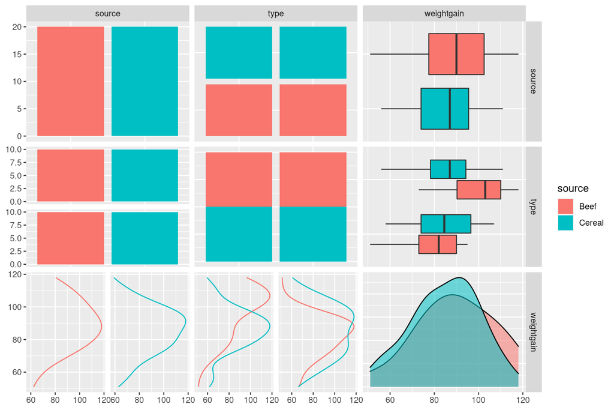

```r
# La función ggpairs proviene del paquete GGally
pm <- ggpairs(weightgain, mapping = aes(color = source),
        lower = list(combo = "facetdensity"),
        legend = 1
        )
# Añadimos transparencia al diagrama de densidad de la celda (3,3)
pm[3,3] <- pm[3,3] + aes(alpha = 0.5)
pm
```

## 1.3 ANOVA

A continuación, reproducimos el cálculo del modelo ANOVA sobre los datos del experimento.

```r
# Cálculo de un modelo anova
# Variable respuesta: weightgain
# Entradas: source + type + source:type
# Fórmula: weightgain ~ source + type + source:type
# El operador * permite compactar la representación de este modelo
# en la fórmula
wg_aov <- aov(weightgain ~ source * type, data = weightgain)

# Resumen de resultados del modelo
summary(wg_aov)
```

```
            Df Sum Sq Mean Sq F value Pr(>F)
source       1    221   220.9   0.988 0.3269
type         1   1300  1299.6   5.812 0.0211 *
source:type  1    884   883.6   3.952 0.0545 .
Residuals   36   8049   223.6
---
Signif. codes:  0 '***' 0.001 '**' 0.01 '*' 0.05 '.' 0.1 ' ' 1
```

Extraemos los coeficientes correspondientes a cada variable. Los niveles de referencia son los escogidos por defecto en el contraste estándar de R, es decir, en este caso `source = "Beef"` y `type = "High"`.

```r
# Coeficientes asociados al modelo
coef(wg_aov)
```

```
         (Intercept)         sourceCereal              typeLow
               100.0                -14.1                -20.8
sourceCereal:typeLow
                18.8
```

Finalmente, representamos un gráfico con los efectos univariantes que podemos captar en el diseño experimental.

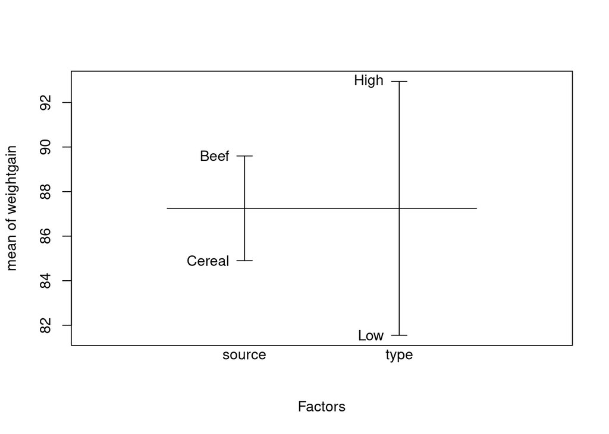

Gráfico que representa los efectos univariantes de cada nivel de las variables categóricas analizadas en el experimento.

```r
plot.design(weightgain)
```

## 1.4 Referencias

- (Hothorn & Everitt, 2014) Torsten Hothorn and Brian S. Everitt (2014). *A Handbook of Statistical Analyses Using R*, Chapman & Hall/CRC.
- (Hand et al, 1994) D. J. Hand, F. Daly, A. D. Lunn, K. J. McConway and E. Ostrowski (1994). *A Handbook of Small Datasets*, Chapman and Hall/CRC, London.